# Practical 2

Lorenzo Occelli

19-09-2022

```r
library(ISLR)
library(ggplot2)
library(tidyr)
library(tidyverse)
data <- Hitters
```

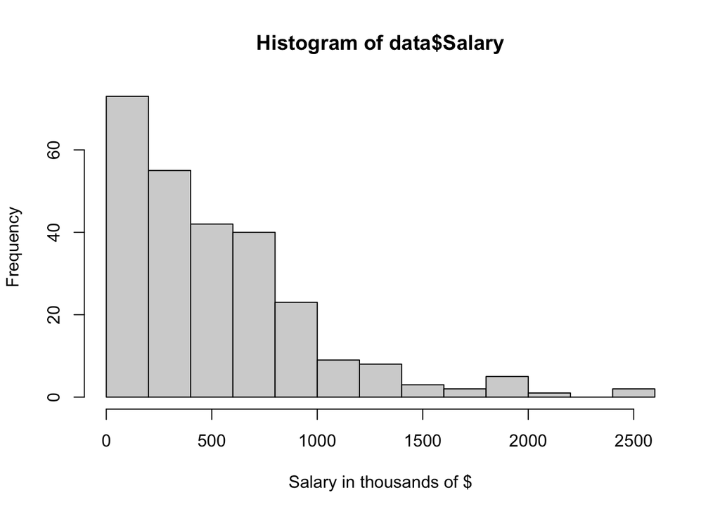

```r
hist(data$Salary, xlab = "Salary in thousands of $")
```

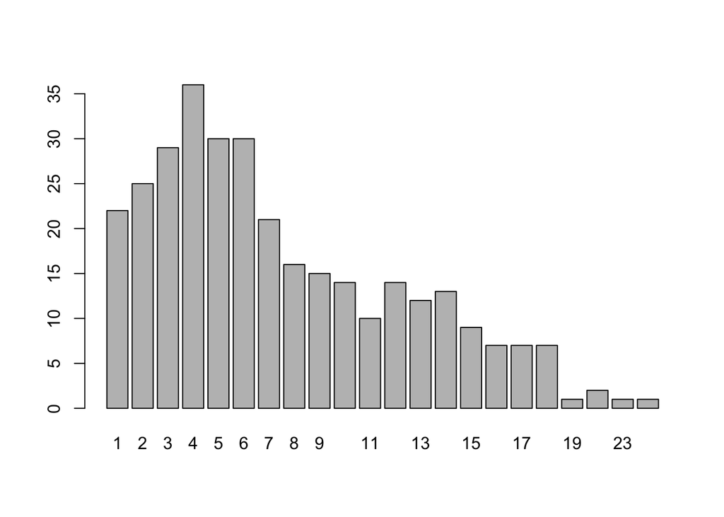

```r
barplot(table(data$Years))
```

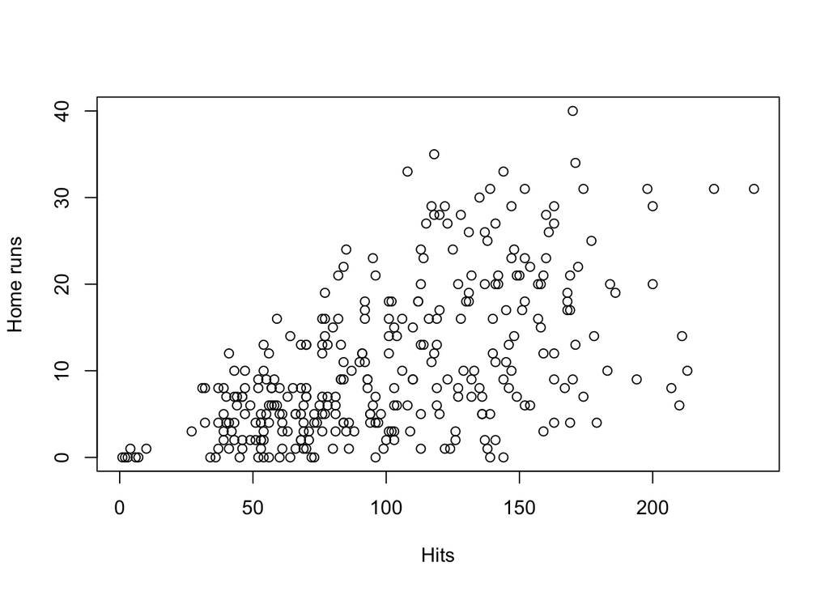

```r
plot(x = data$Hits, y = data$HmRun, xlab = "Hits", ylab = "Home runs")
```

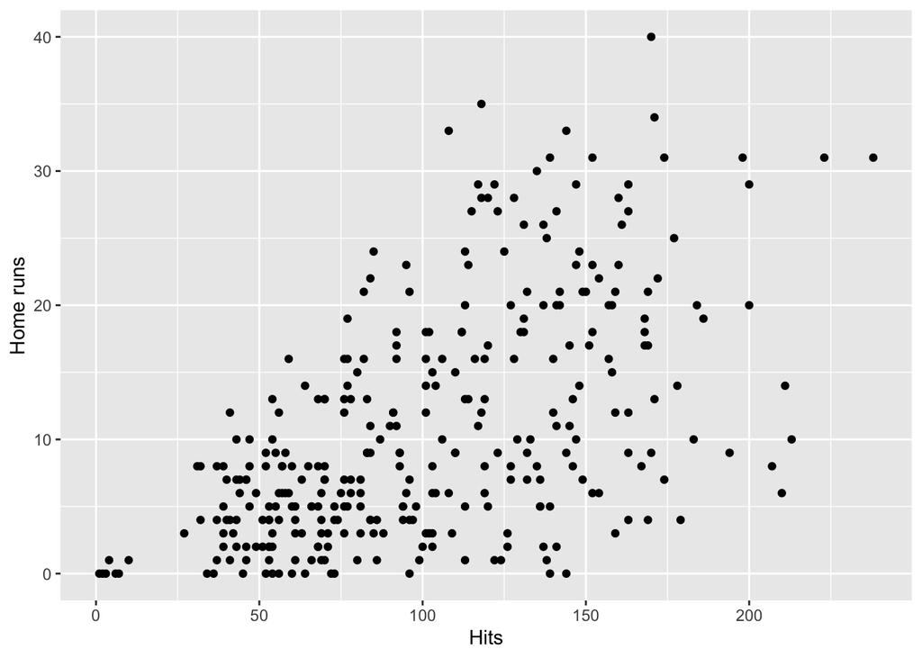

```r
homeruns_plot <-
  ggplot(data, aes(x= Hits, y = HmRun)) +
  geom_point() +
  labs(x = "Hits", y = "Home runs")

homeruns_plot
```

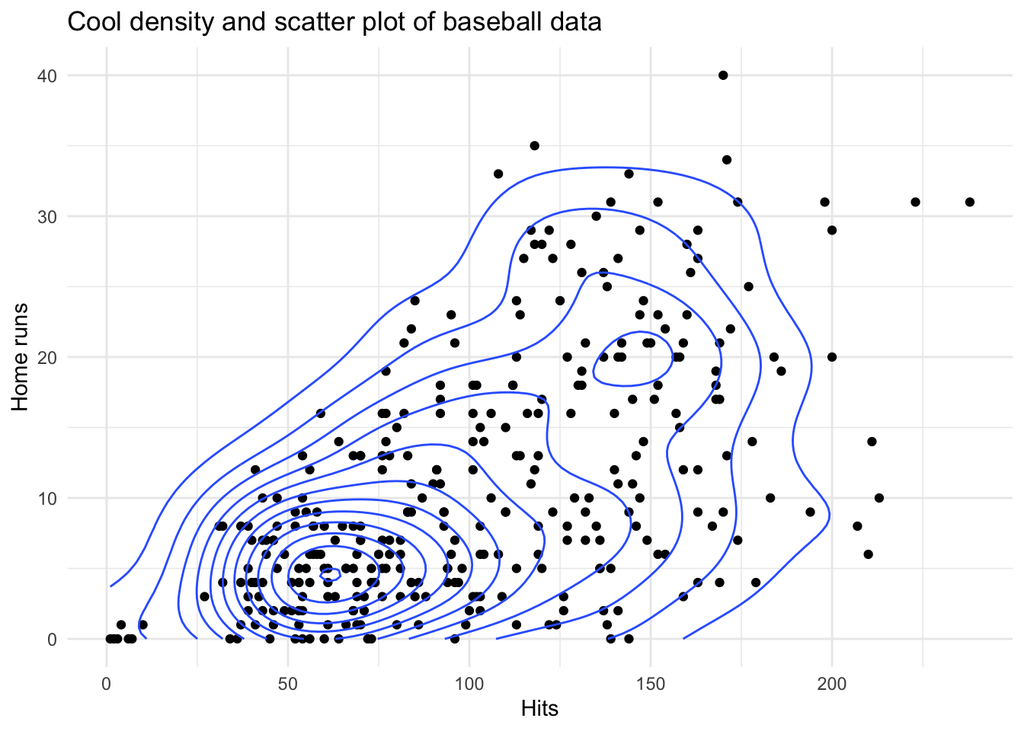

```r
homeruns_plot +
  geom_density_2d() +
  labs(title = "Cool density and scatter plot of baseball data") +
  theme_minimal()
```

```r
set.seed(1234)
student_grade  <- rnorm(32, 7)
student_number <- round(runif(32) * 2e6 + 5e6)
programme      <- sample(c("Science", "Social Science"), 32, replace = TRUE)
```

```r
gg_students <-
  tibble(
    ID = as.character(student_number),
    grade = student_grade,
    programme = as.factor(programme))

head(gg_students)
```

| ID | grade | programme |
| --- | --- | --- |
| 5478051 | 5.792934 | Social Science |
| 6412989 | 7.277429 | Science |
| 5616190 | 8.084441 | Social Science |
| 6017095 | 4.654302 | Social Science |
| 5103293 | 7.429125 | Social Science |
| 6129140 | 7.506056 | Science |

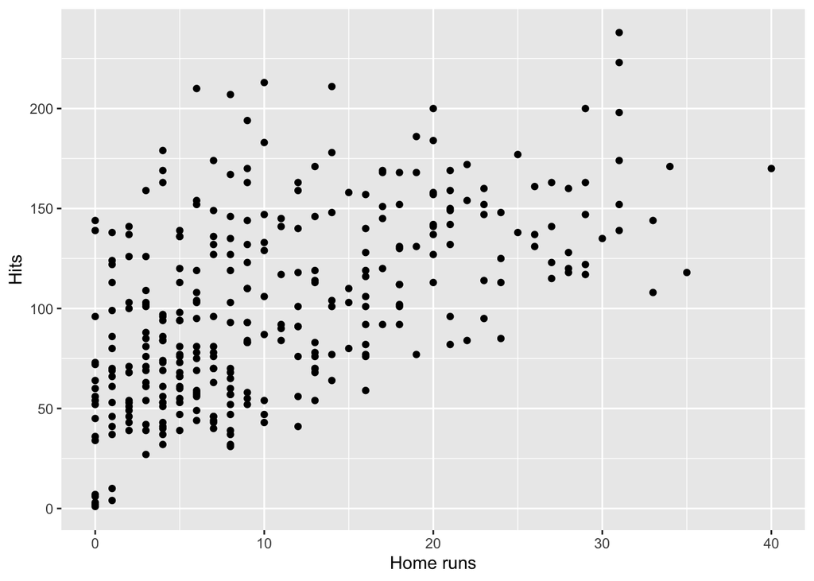

```r
homeruns_plot_rev <-
  ggplot(data, aes(x= HmRun, y = Hits)) +
  geom_point() +
  labs(x = "Home runs", y = "Hits")

homeruns_plot_rev
```

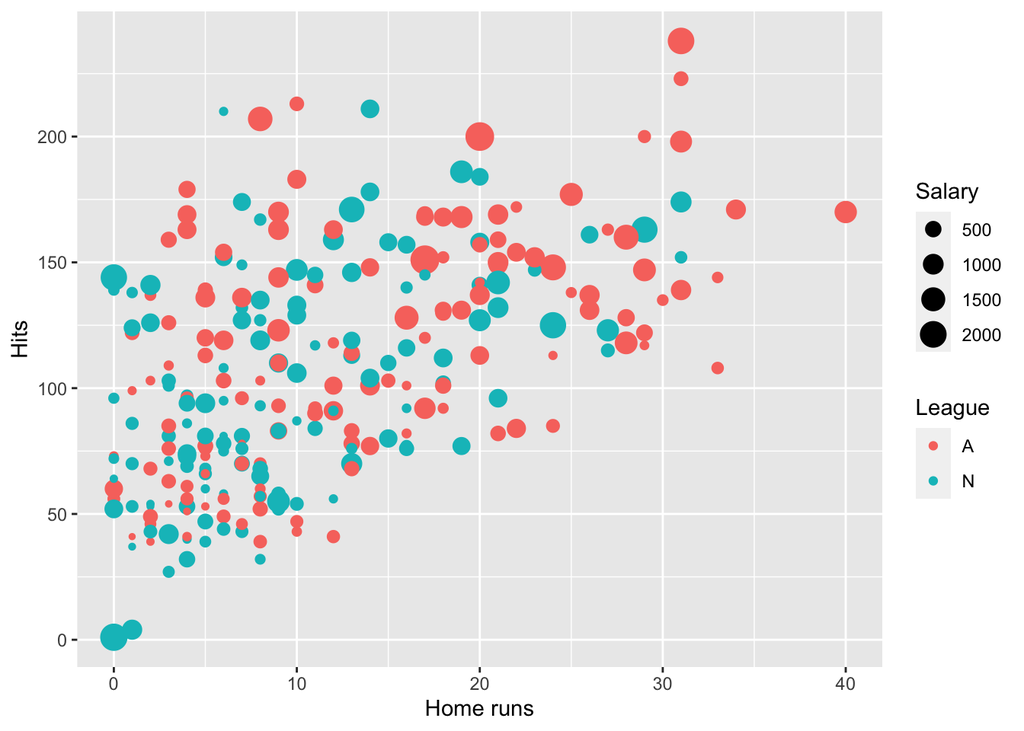

```r
homeruns_plot_new <-
  ggplot(data, aes(x= HmRun, y = Hits, colour = League, size = Salary)) +
  geom_point() +
  labs(x = "Home runs", y = "Hits")

homeruns_plot_new
```

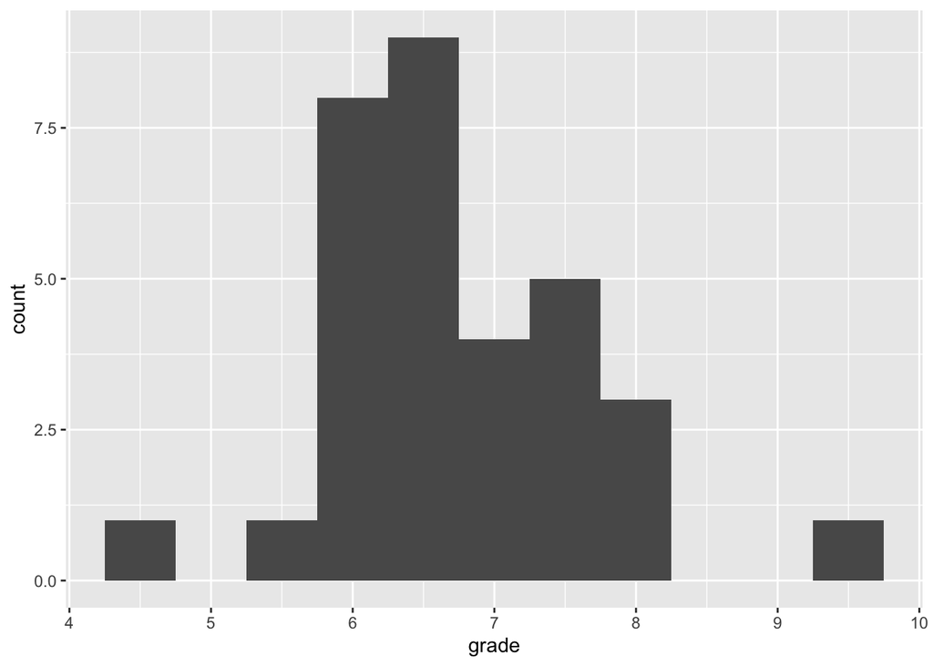

```r
students_hist <-
  ggplot(gg_students, aes(x = grade)) +
  geom_histogram(binwidth = 0.5)

students_hist
```

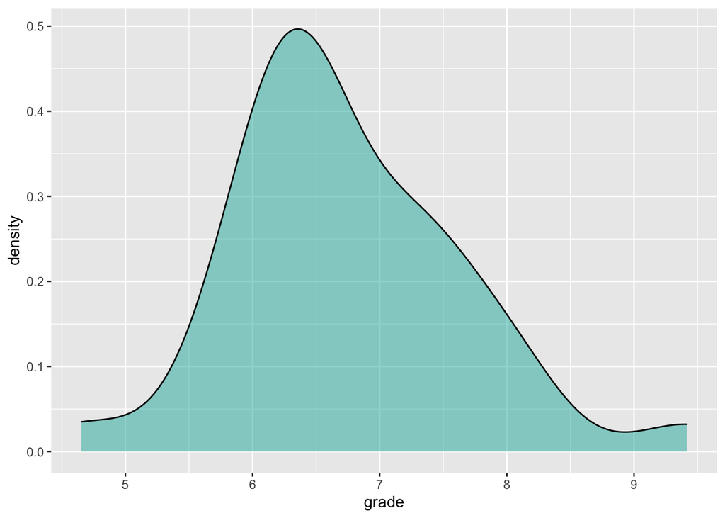

```r
students_density <-
  ggplot(gg_students, aes(x = grade)) +
  geom_density(fill = "light seagreen", alpha = 0.5)

students_density
```

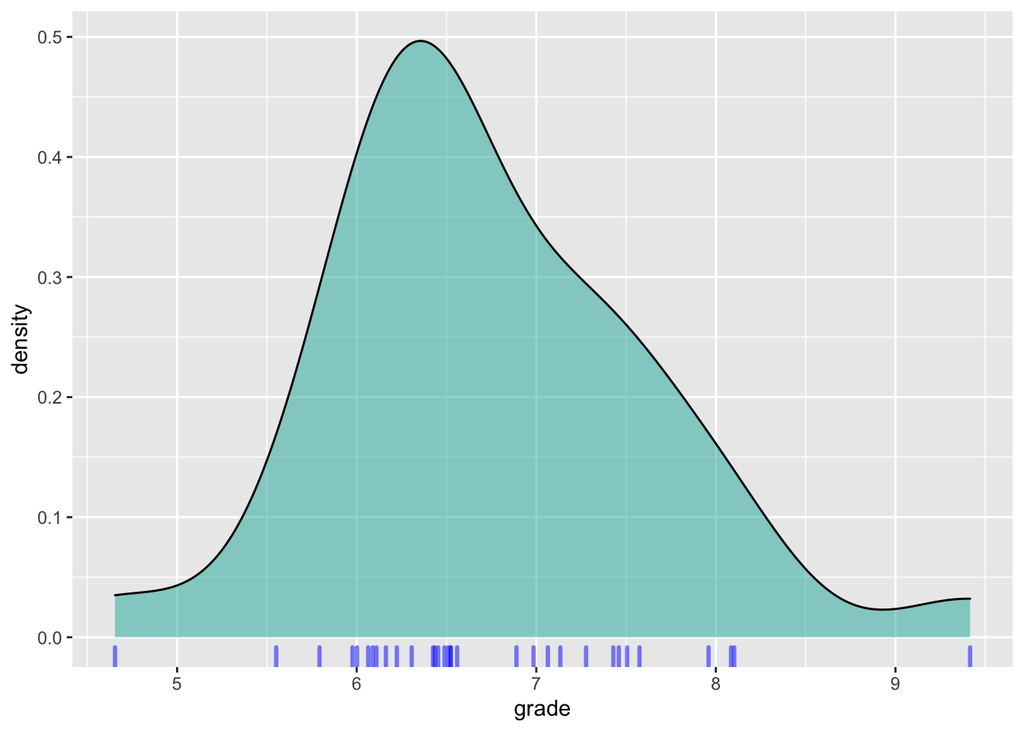

```r
students_density +
  geom_rug(colour = "blue", alpha = 0.5, size = 1)
```

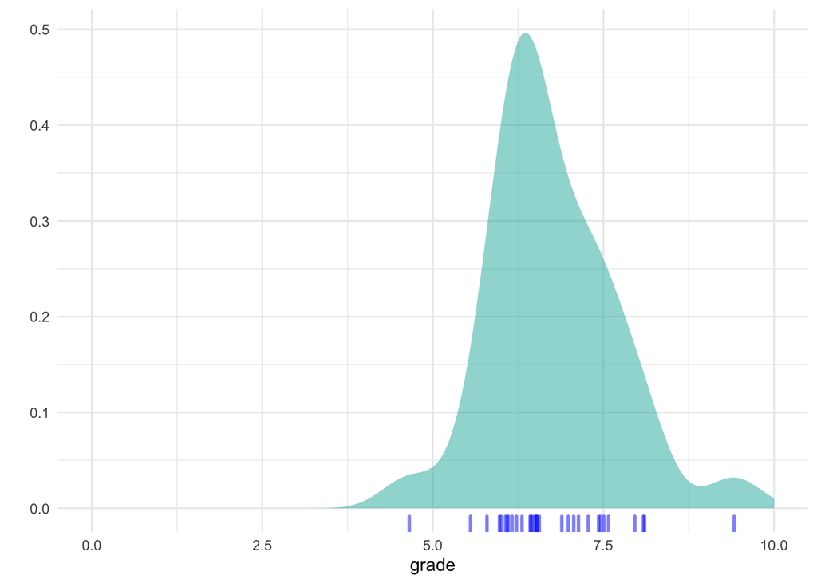

```r
students_density2 <-
  ggplot(gg_students, aes(x = grade)) +
  geom_density(fill = "light seagreen", alpha = 0.5,
  linetype = 0) +
  geom_rug(colour = "blue", alpha = 0.5, size = 1) +
  labs(y = "") +
  theme_minimal() +
  xlim(0, 10)

students_density2
```

I could not find a better way to remove the border of the density polygon using the linetype = 0.

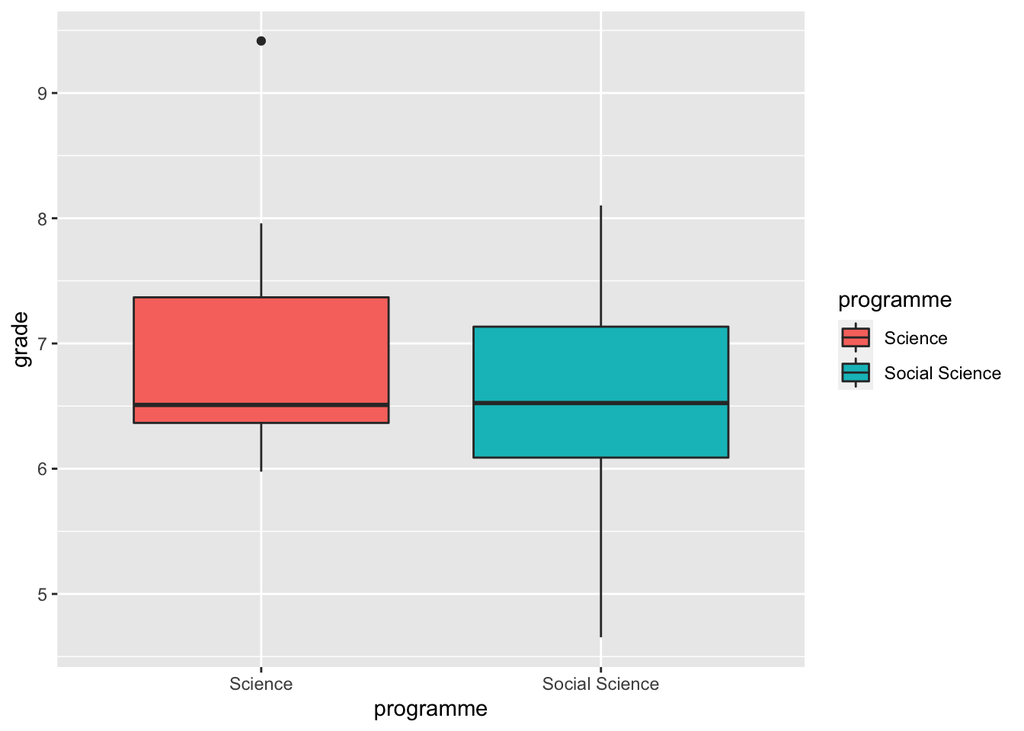

```r
gg_students %>%
  ggplot(aes(x = programme, y = grade, fill = programme)) +
  geom_boxplot()
```

The thick horizontal lines inside the boxes represent the 50th quartile, or median of our data.  
The lower and upper ends of the boxes are instead the first and the third quartile.  
The whiskers, to conclude, delimit the minimum and the maximum value of our set of data. We have to point out that they include only values no further than 1.5 * IQR from the hinge (where IQR is the inter-quartile range, or distance between the first and third quartiles). All values outside this range are classified as outliers, and are represented as single dots.

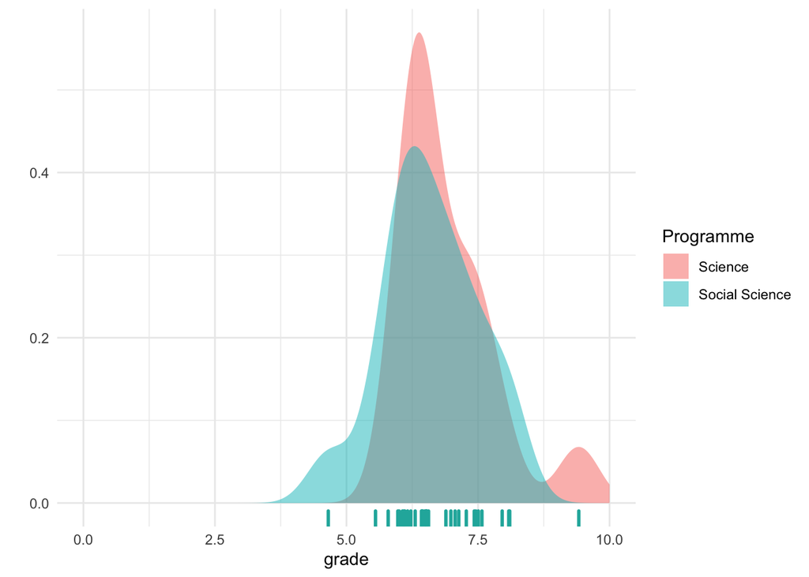

```r
gg_students %>%
  ggplot(aes(x = grade, fill = programme)) +
  geom_density(alpha = .5, colour = NA) +
  geom_rug(size = 1, colour = "light seagreen") +
  theme_minimal() +
  labs(y = "", fill = "Programme") +
  xlim(0, 10)
```

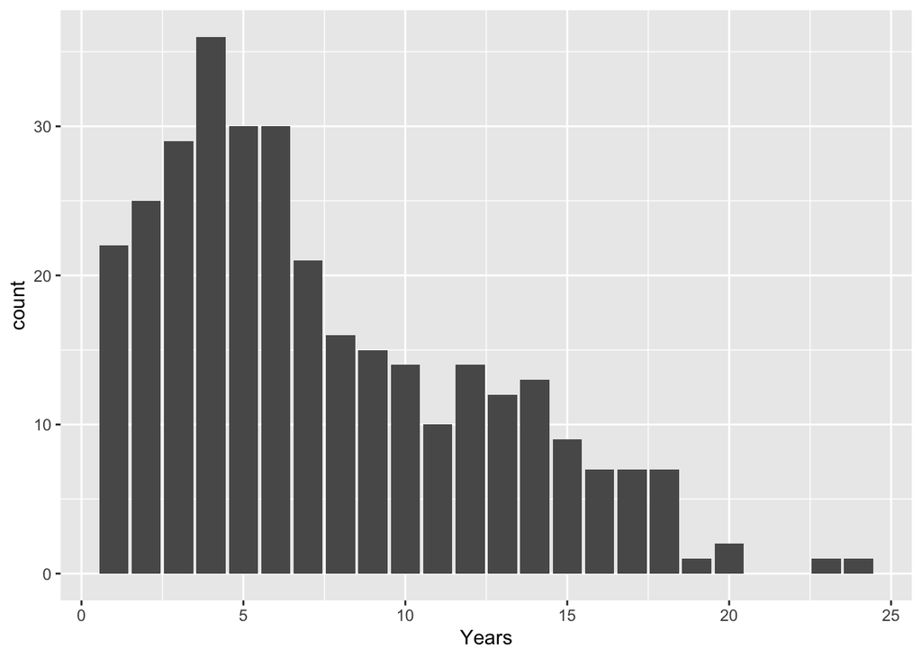

```r
data %>%
  ggplot(aes(x=Years)) +
  geom_bar()
```

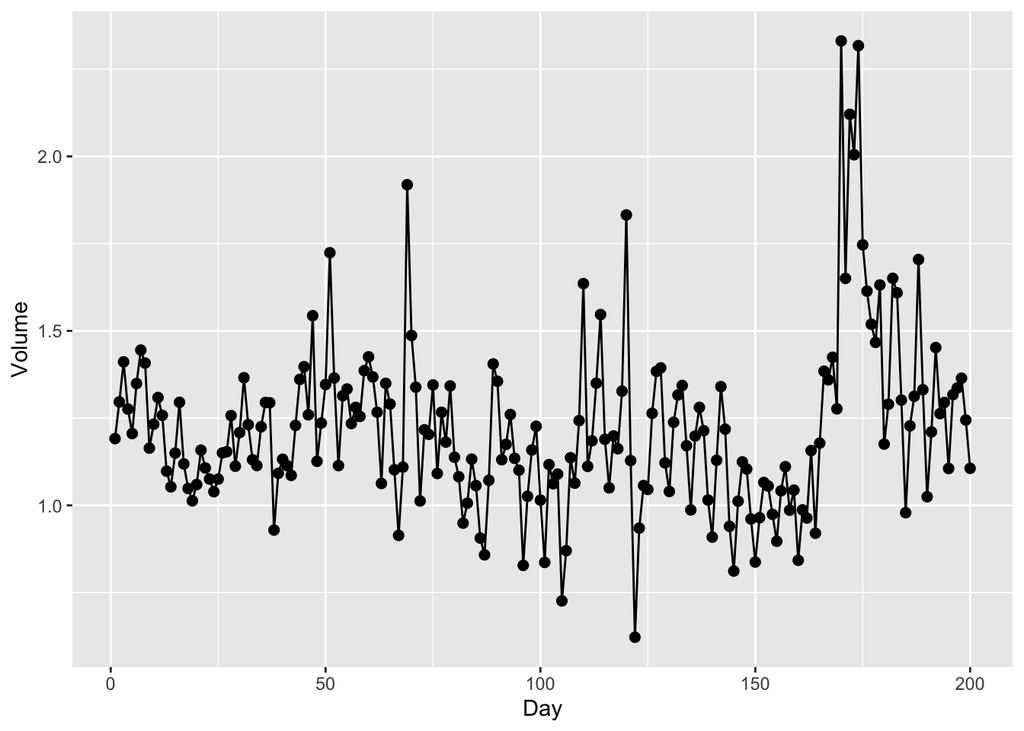

```r
Smarket[1:200,] %>%
    mutate(Day = 1:200) %>%
    ggplot(aes(x = Day, y = Volume)) +
    geom_line() +
    geom_point(size=2)
```

```r
which.max(Smarket[1:200,]$Volume)
```

```
## [1] 170
```

```r
max(Smarket[1:200,]$Volume)
```

```
## [1] 2.33083
```

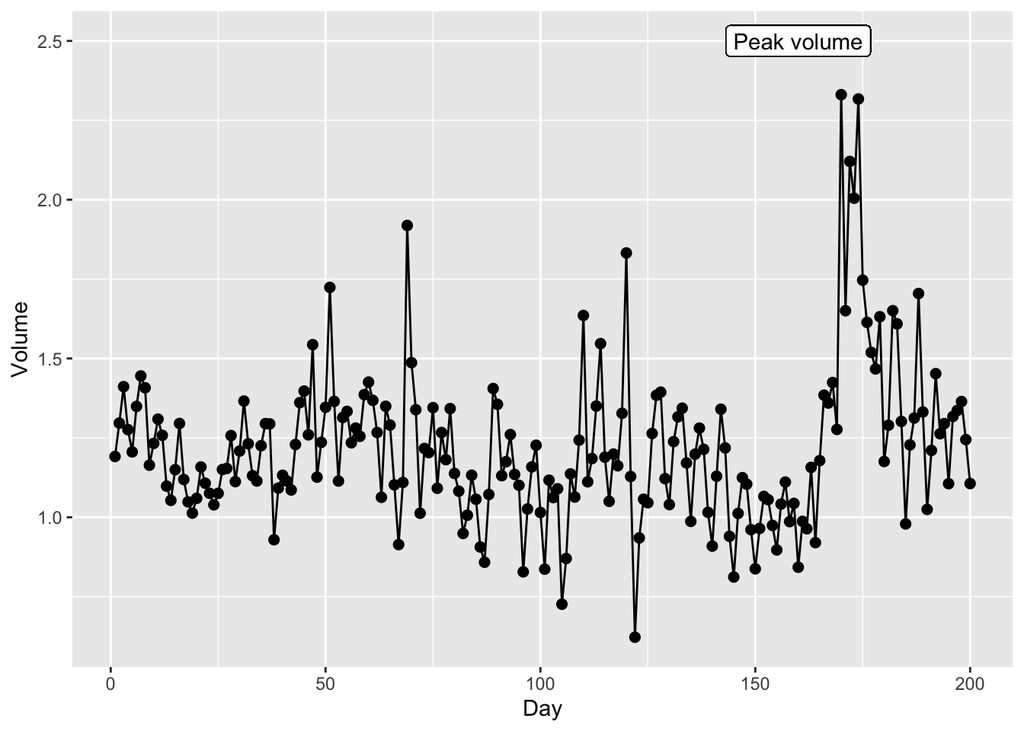

```r
Smarket[1:200,] %>%
    mutate(Day = 1:200) %>%
    ggplot(aes(x = Day, y = Volume)) +
    geom_line() +
    geom_point(size=2) +
    geom_label(aes(x = 160, y = 2.5, label="Peak volume"))
```

```r
baseball <-
  Hitters %>%
    filter(!is.na(Salary)) %>%
    mutate(Salary_range = cut(Salary, breaks = 3,
                       labels = c("Low salary", "Mid salary", "High salary")),
    Career_hmrun_proportion = CHmRun/CHits)
```

```r
baseball_plot <-
baseball %>%
  ggplot(aes(x = CWalks, y = Career_hmrun_proportion)) +
  geom_point() +
  ylim(0, 0.4) +
  xlim(0, 1600) +
  xlab("# walks during the carrer") +
  ylab("carrer hits/home run")
```

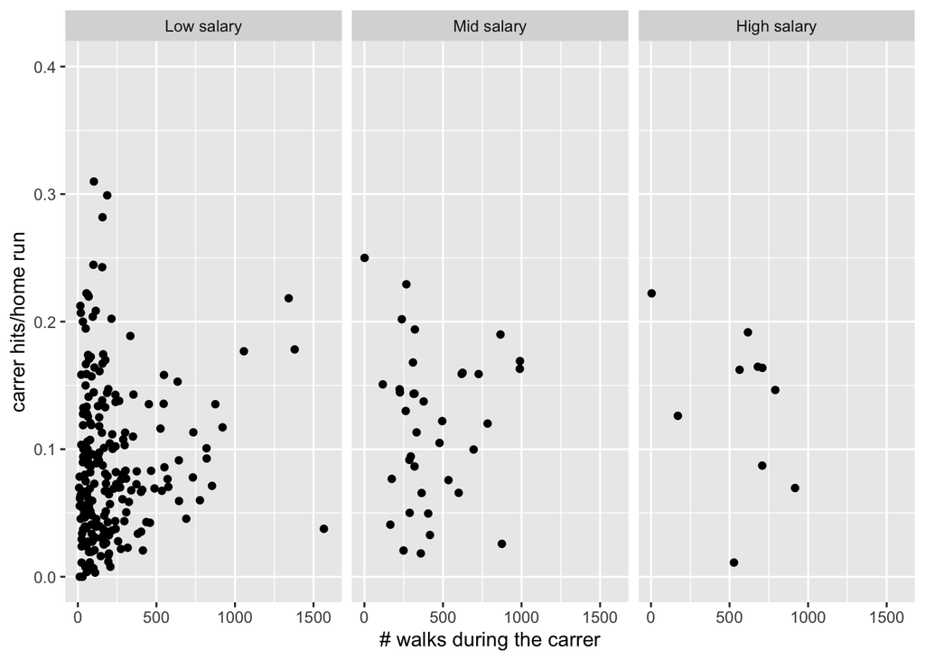

```r
baseball_plot + facet_wrap(~Salary_range)
```

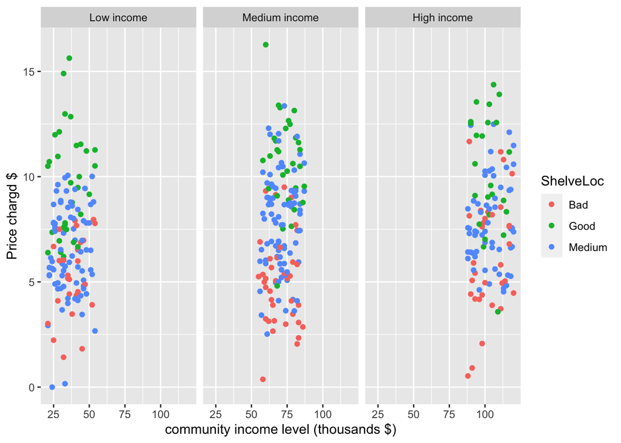

```r
Carseats_new <-
Carseats %>%
  mutate(Income_level = cut(Income, breaks = 3,
                       labels = c("Low income", "Medium income", "High income")))
Carseats_new %>%
  ggplot(aes(x = Income, y = Sales, color = ShelveLoc))+
  geom_point() +
  xlab("community income level (thousands $)") +
  ylab("Price chargd $") +
  facet_wrap(~Income_level)
```